# nested-models-seminar

1. We can rescale and center continuous parameters (as.numeric(scale(param)))

Большая разница между мин и макс значениями не обязательно портит схождение модели, но такое бывает и лучше исправить эту проблему сразу. (В принципе для этого же и задают контрасты, как вчера на линг данных)

```r
numcols <- grep("^c\\.",names(df))
dfs <- df
dfs[,numcols] <- scale(dfs[,numcols])
m1_sc <- update(m1,data=dfs)
```

2. Singularity Определение: some of the constrained parameters of the random effects theta parameters are on the boundary (equal to zero, or very very close to zero, say <10−6

```r
tt <- getME(m1_sc,"theta")
ll <- getME(m1_sc,"lower")
min(tt[ll==0])
```

```
## [1] 0.007955824
```

Тут всё ок с сингулярностью

3. Restart from previous fit restart the fit from the reported optimum, or from a point perturbed slightly away from the reported optimum

maxfun - maximum number of function evaluations - то есть эта штука увеличает количество итераций

```r
ss <- getME(m1_sc,c("theta","fixef"))
m2 <- update(m1_sc,start=ss,control=glmerControl(optCtrl=list(maxfun=2e4)))
```

4. Попробовать другой оптимизатор (И увеличили количество итераций)

```r
m3 <- update(m1_sc,start=ss,control=glmerControl(optimizer="bobyqa",
                            optCtrl=list(maxfun=2e5)))
```

```
## boundary (singular) fit: see ?isSingular
```

```r
aa <- allFit(m1)
```

```
## bobyqa :
```

```
## boundary (singular) fit: see ?isSingular
```

```
## [OK]
## Nelder_Mead :
```

```
## boundary (singular) fit: see ?isSingular
```

```
## [OK]
## nlminbwrap :
```

```
## [OK]
## nmkbw : [OK]
## optimx.L-BFGS-B : [OK]
## nloptwrap.NLOPT_LN_NELDERMEAD : [OK]
## nloptwrap.NLOPT_LN_BOBYQA : [OK]
```

```r
#library(optimx)
#m4 <- update(m1_sc,start=ss,control=glmerControl(optimizer="optimx"))
```

Давайте ещё раз всё посмотрим на датасете sleepstudy

```r
data("sleepstudy")
head(sleepstudy)
```

```
##   Reaction Days Subject
## 1 249.5600    0     308
## 2 258.7047    1     308
## 3 250.8006    2     308
## 4 321.4398    3     308
## 5 356.8519    4     308
## 6 414.6901    5     308
```

```r
fm1 <- lmer(Reaction ~ Days + Days^2 + (Days | Subject), data=sleepstudy)
summary(fm1)
```

```
## Linear mixed model fit by REML ['lmerMod']
## Formula: Reaction ~ Days + Days^2 + (Days | Subject)
##    Data: sleepstudy
##
## REML criterion at convergence: 1743.6
##
## Scaled residuals:
##     Min      1Q  Median      3Q     Max
## -3.9536 -0.4634  0.0231  0.4633  5.1793
##
## Random effects:
##  Groups   Name        Variance Std.Dev. Corr
##  Subject  (Intercept) 611.90   24.737
##           Days         35.08    5.923   0.07
##  Residual             654.94   25.592
## Number of obs: 180, groups:  Subject, 18
##
## Fixed effects:
##             Estimate Std. Error t value
## (Intercept)  251.405      6.824  36.843
## Days          10.467      1.546   6.771
##
## Correlation of Fixed Effects:
##      (Intr)
## Days -0.138
```

Scale parameters:

```r
## 2. center and scale predictors:
ss.CS <- transform(sleepstudy, Days=scale(Days))
fm1.CS <- update(fm1, data=ss.CS)
```

decrease stopping tolerances

```r
strict_tol <- lmerControl(optCtrl=list(xtol_abs=1e-8, ftol_abs=1e-8))
if (all(fm1@optinfo$optimizer=="nloptwrap")) {
    fm1.tol <- update(fm1, control=strict_tol)
}
```

try all available optimizers

```r
  fm1.all <- allFit(fm1)
```

```
## bobyqa : [OK]
## Nelder_Mead : [OK]
## nlminbwrap : [OK]
## nmkbw : [OK]
## optimx.L-BFGS-B : [OK]
## nloptwrap.NLOPT_LN_NELDERMEAD : [OK]
## nloptwrap.NLOPT_LN_BOBYQA : [OK]
```

```r
  ss <- summary(fm1.all)
  ss$ fixef               ## fixed effects
```

```
##                               (Intercept)     Days
## bobyqa                           251.4051 10.46729
## Nelder_Mead                      251.4051 10.46729
## nlminbwrap                       251.4051 10.46729
## nmkbw                            251.4051 10.46729
## nloptwrap.NLOPT_LN_NELDERMEAD    251.4051 10.46729
## nloptwrap.NLOPT_LN_BOBYQA        251.4051 10.46729
```

```r
  ss$ llik                ## log-likelihoods
```

```
##                        bobyqa                   Nelder_Mead
##                     -871.8141                     -871.8141
##                    nlminbwrap                         nmkbw
##                     -871.8141                     -871.8141
## nloptwrap.NLOPT_LN_NELDERMEAD     nloptwrap.NLOPT_LN_BOBYQA
##                     -871.8141                     -871.8141
```

```r
  ss$ sdcor               ## SDs and correlations
```

```
##                               Subject.(Intercept) Subject.Days.(Intercept)
## bobyqa                                   24.74045                 5.922133
## Nelder_Mead                              24.74061                 5.922142
## nlminbwrap                               24.74045                 5.922114
## nmkbw                                    24.73847                 5.922334
## nloptwrap.NLOPT_LN_NELDERMEAD            24.73656                 5.922927
## nloptwrap.NLOPT_LN_BOBYQA                24.73656                 5.922927
##                               Subject.Days    sigma
## bobyqa                          0.06555133 25.59182
## Nelder_Mead                     0.06555186 25.59180
## nlminbwrap                      0.06556275 25.59182
## nmkbw                           0.06560917 25.59189
## nloptwrap.NLOPT_LN_NELDERMEAD   0.06561803 25.59181
## nloptwrap.NLOPT_LN_BOBYQA       0.06561803 25.59181
```

```r
  ss$ theta               ## Cholesky factors
```

```
##                               Subject.(Intercept) Subject.Days.(Intercept)
## bobyqa                                  0.9667328               0.01516906
## Nelder_Mead                             0.9667396               0.01516921
## nlminbwrap                              0.9667328               0.01517165
## nmkbw                                   0.9666526               0.01518291
## nloptwrap.NLOPT_LN_NELDERMEAD           0.9665812               0.01518653
## nloptwrap.NLOPT_LN_BOBYQA               0.9665812               0.01518653
##                               Subject.Days
## bobyqa                           0.2309096
## Nelder_Mead                      0.2309101
## nlminbwrap                       0.2309087
## nmkbw                            0.2309159
## nloptwrap.NLOPT_LN_NELDERMEAD    0.2309396
## nloptwrap.NLOPT_LN_BOBYQA        0.2309396
```

```r
  ss$ which.OK            ## which fits worked
```

```
##                        bobyqa                   Nelder_Mead
##                          TRUE                          TRUE
##                    nlminbwrap                         nmkbw
##                          TRUE                          TRUE
##               optimx.L-BFGS-B nloptwrap.NLOPT_LN_NELDERMEAD
##                         FALSE                          TRUE
##     nloptwrap.NLOPT_LN_BOBYQA
##                          TRUE
```

## Длинные драконы с разных гор

```r
load('dragons.RData')
head(dragons)
```

```
##   testScore bodyLength mountainRange site
## 1 16.147309   165.5485      Bavarian    a
## 2 33.886183   167.5593      Bavarian    a
## 3  6.038333   165.8830      Bavarian    a
## 4 18.838821   167.6855      Bavarian    a
## 5 33.862328   169.9597      Bavarian    a
## 6 47.043246   168.6887      Bavarian    a
```

Короче мы поехали в горы и замерили там длину тела дракона и все драконы прошли тест на интеллектуальный уровень. И нам интересно, зависит ли testscore от длины дракона

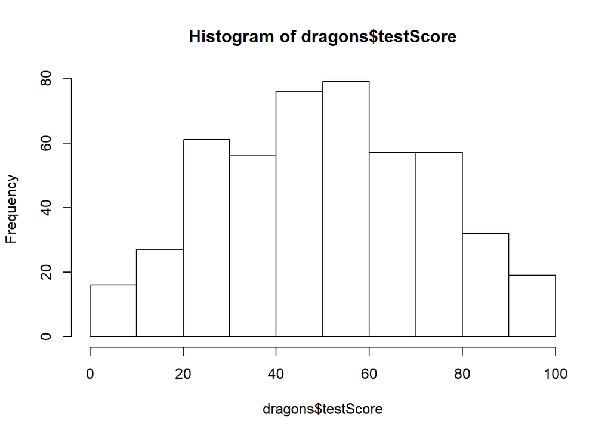

```r
hist(dragons$testScore)  # normal distribution
```

```r
dragons$bodyLength2 <- scale(dragons$bodyLength)
head(dragons)
```

```
##   testScore bodyLength mountainRange site bodyLength2
## 1 16.147309   165.5485      Bavarian    a   -2.206233
## 2 33.886183   167.5593      Bavarian    a   -2.082204
## 3  6.038333   165.8830      Bavarian    a   -2.185605
## 4 18.838821   167.6855      Bavarian    a   -2.074419
## 5 33.862328   169.9597      Bavarian    a   -1.934145
## 6 47.043246   168.6887      Bavarian    a   -2.012538
```

```r
basic.lm <- lm(testScore ~ bodyLength2, data = dragons)
summary(basic.lm)
```

```
##
## Call:
## lm(formula = testScore ~ bodyLength2, data = dragons)
##
## Residuals:
##     Min      1Q  Median      3Q     Max
## -56.962 -16.411  -0.783  15.193  55.200
##
## Coefficients:
##             Estimate Std. Error t value Pr(>|t|)
## (Intercept)  50.3860     0.9676  52.072   <2e-16 ***
## bodyLength2   8.9956     0.9686   9.287   <2e-16 ***
## ---
## Signif. codes:  0 '***' 0.001 '**' 0.01 '*' 0.05 '.' 0.1 ' ' 1
##
## Residual standard error: 21.2 on 478 degrees of freedom
## Multiple R-squared:  0.1529, Adjusted R-squared:  0.1511
## F-statistic: 86.25 on 1 and 478 DF,  p-value: < 2.2e-16
```

Уже надоели эти preliminary plots, но что поделать

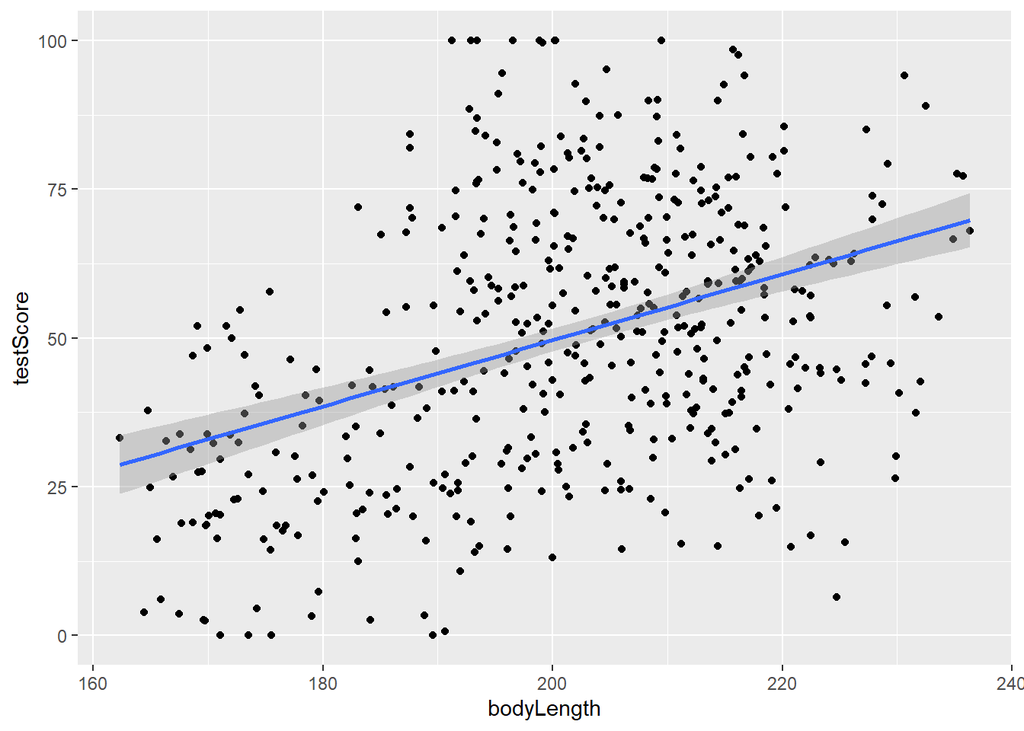

```r
(prelim_plot <- ggplot(dragons, aes(x = bodyLength, y = testScore)) +
  geom_point() +
  geom_smooth(method = "lm"))
```

Аа что? Более большие драконы - более умные?

Красная линия должна быть почти ровная

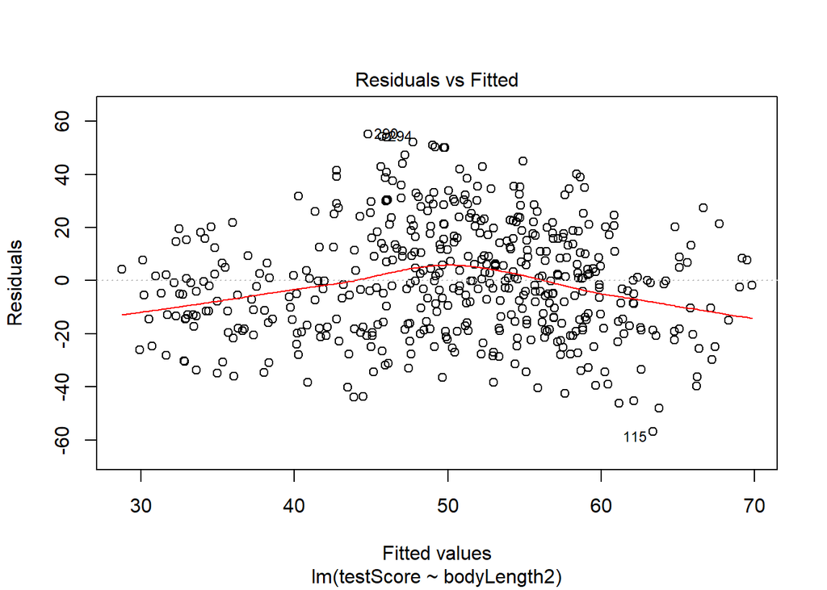

```r
plot(basic.lm, which = 1)
```

Ну тут тоже ничего

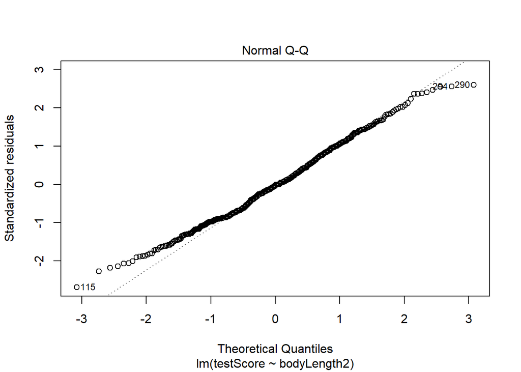

```r
plot(basic.lm, which = 2)
```

Тогда проверим на независимость наблюдений. Упс у нас есть какие-то тренды в зависимости от того, из каких гор эти драконы

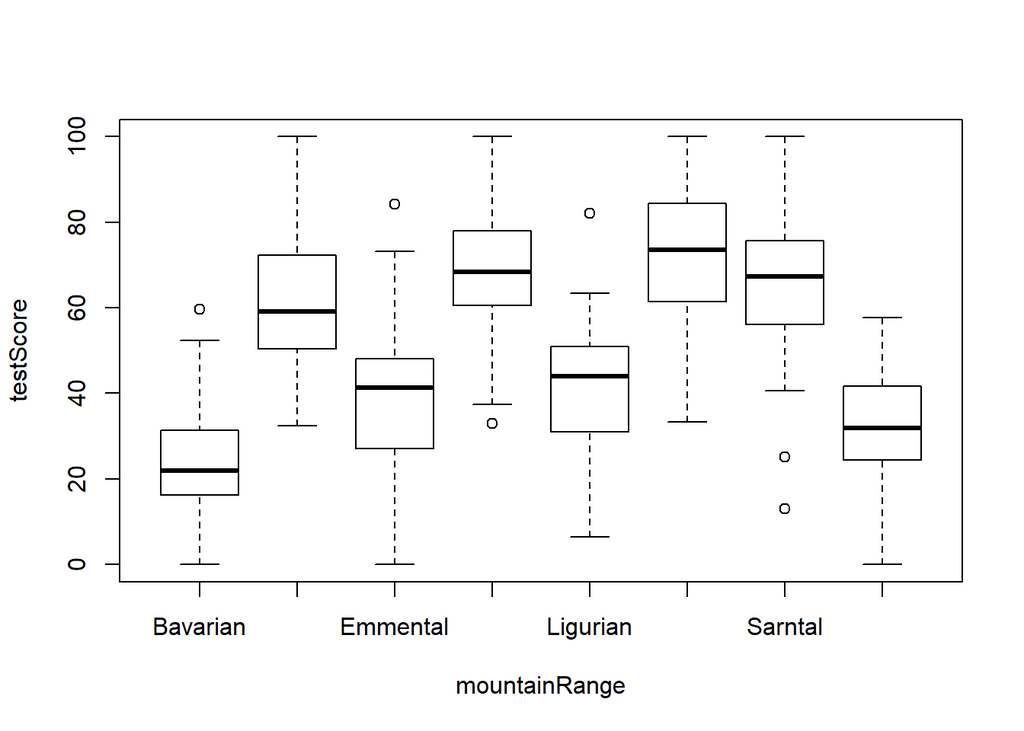

```r
boxplot(testScore ~ mountainRange, data = dragons)
```

Появляются какие-то группки. Это значит, что наблюдения с одного горного массива зависят друг от друга

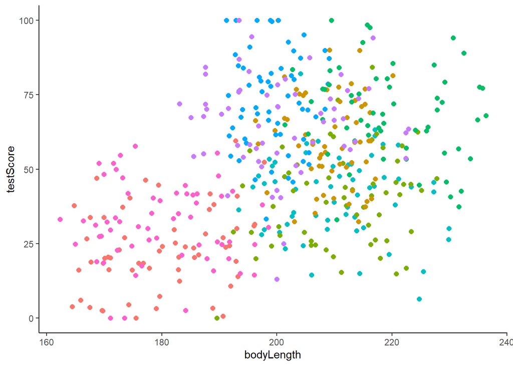

```r
(colour_plot <- ggplot(dragons, aes(x = bodyLength, y = testScore, colour = mountainRange)) +
  geom_point(size = 2) +
  theme_classic() +
  theme(legend.position = "none"))
```

Больше графиков

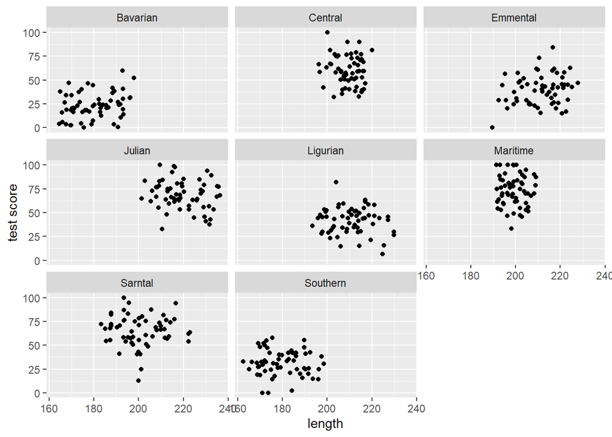

```r
(split_plot <- ggplot(aes(bodyLength, testScore), data = dragons) +
  geom_point() +
  facet_wrap(~ mountainRange) +
  xlab("length") +
  ylab("test score"))
```

We would have to estimate a slope and intercept parameter for each regression. That’s two parameters, three sites and eight mountain ranges, which means 48 parameter estimates (2 x 3 x 8 = 48)! Moreover, the sample size for each analysis would be only 20.

This presents problems: not only are we hugely decreasing our sample size, but we are also increasing chances of a Type I Error (where you falsely reject the null hypothesis) by carrying out multiple comparisons. Не очень!

```r
mountain.lm <- lm(testScore ~ bodyLength2 + mountainRange, data = dragons)
summary(mountain.lm)
```

```
##
## Call:
## lm(formula = testScore ~ bodyLength2 + mountainRange, data = dragons)
##
## Residuals:
##     Min      1Q  Median      3Q     Max
## -52.263  -9.926   0.361   9.994  44.488
##
## Coefficients:
##                       Estimate Std. Error t value Pr(>|t|)
## (Intercept)            23.3818     2.5792   9.065  < 2e-16 ***
## bodyLength2             0.2055     1.2927   0.159  0.87379
## mountainRangeCentral   36.5828     3.5993  10.164  < 2e-16 ***
## mountainRangeEmmental  16.2092     3.6966   4.385 1.43e-05 ***
## mountainRangeJulian    45.1147     4.1901  10.767  < 2e-16 ***
## mountainRangeLigurian  17.7478     3.6736   4.831 1.84e-06 ***
## mountainRangeMaritime  49.8813     3.1392  15.890  < 2e-16 ***
## mountainRangeSarntal   41.9784     3.1972  13.130  < 2e-16 ***
## mountainRangeSouthern   8.5196     2.7313   3.119  0.00192 **
## ---
## Signif. codes:  0 '***' 0.001 '**' 0.01 '*' 0.05 '.' 0.1 ' ' 1
##
## Residual standard error: 14.96 on 471 degrees of freedom
## Multiple R-squared:  0.5843, Adjusted R-squared:  0.5773
## F-statistic: 82.76 on 8 and 471 DF,  p-value: < 2.2e-16
```

Упс, длина драконов стала неважна(( — плохо we are looking to control for the effects of mountain range. We haven’t sampled all the mountain ranges in the world (we have eight) so our data are just a sample of all the existing mountain ranges. We are not really interested in the effect of each specific mountain range on the test score, but we know that the test scores from within the ranges might be correlated so we want to control for that

```r
mixed.lmer <- lmer(testScore ~ bodyLength2 + (1|mountainRange), data = dragons)
summary(mixed.lmer)
```

```
## Linear mixed model fit by REML ['lmerMod']
## Formula: testScore ~ bodyLength2 + (1 | mountainRange)
##    Data: dragons
##
## REML criterion at convergence: 3985.6
##
## Scaled residuals:
##     Min      1Q  Median      3Q     Max
## -3.4815 -0.6513  0.0066  0.6685  2.9583
##
## Random effects:
##  Groups        Name        Variance Std.Dev.
##  mountainRange (Intercept) 339.7    18.43
##  Residual                  223.8    14.96
## Number of obs: 480, groups:  mountainRange, 8
##
## Fixed effects:
##             Estimate Std. Error t value
## (Intercept)  50.3860     6.5517   7.690
## bodyLength2   0.5377     1.2750   0.422
##
## Correlation of Fixed Effects:
##             (Intr)
## bodyLength2 0.000
```

t-value очень маленькое. Эффект не значительный

Авторы этого датасета, кстати, говорят, что это нехорошо включать род в случайные эффекты. По их мнению, случайные переменные должны иметь хотя бы 5 уровней, а у пола только два уровня.

Так вот. Длина драконов не влияет на их интеллект

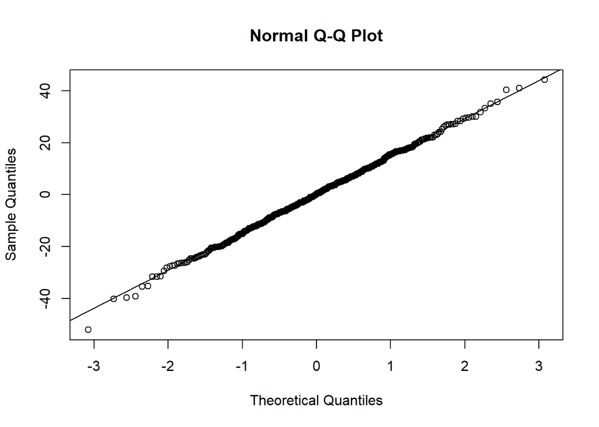

```r
qqnorm(resid(mixed.lmer))
qqline(resid(mixed.lmer))  # good
```

```r
summary(mixed.lmer)
```

```
## Linear mixed model fit by REML ['lmerMod']
## Formula: testScore ~ bodyLength2 + (1 | mountainRange)
##    Data: dragons
##
## REML criterion at convergence: 3985.6
##
## Scaled residuals:
##     Min      1Q  Median      3Q     Max
## -3.4815 -0.6513  0.0066  0.6685  2.9583
##
## Random effects:
##  Groups        Name        Variance Std.Dev.
##  mountainRange (Intercept) 339.7    18.43
##  Residual                  223.8    14.96
## Number of obs: 480, groups:  mountainRange, 8
##
## Fixed effects:
##             Estimate Std. Error t value
## (Intercept)  50.3860     6.5517   7.690
## bodyLength2   0.5377     1.2750   0.422
##
## Correlation of Fixed Effects:
##             (Intr)
## bodyLength2 0.000
```

Посмотрим еще раз внимательно на наши случайные эффекты

Горы объясняет большую часть дисперсии. Они явно как-то сильно влияют

Do keep in mind that’s 60% of variance “left over” after the variance explained by our fixed effects.

```r
339.7/(339.7 + 223.8)  # ~60 %
```

```
## [1] 0.6028394
```

Explicit nesting - это самый адекватный подход при использовании пакета lme4. При работе с nlme() можно и без этого

Нужно избегать имплицитной иерархической организации данных, потому что lme4 как мы уже выяснили на примере schooldata очень фигово различает crossed Vs nested effects

```r
dragons <- within(dragons, sample <- factor(mountainRange:site))
head(dragons)
```

```
##   testScore bodyLength mountainRange site bodyLength2     sample
## 1 16.147309   165.5485      Bavarian    a   -2.206233 Bavarian:a
## 2 33.886183   167.5593      Bavarian    a   -2.082204 Bavarian:a
## 3  6.038333   165.8830      Bavarian    a   -2.185605 Bavarian:a
## 4 18.838821   167.6855      Bavarian    a   -2.074419 Bavarian:a
## 5 33.862328   169.9597      Bavarian    a   -1.934145 Bavarian:a
## 6 47.043246   168.6887      Bavarian    a   -2.012538 Bavarian:a
```

```r
str(dragons)
```

```
## 'data.frame':    480 obs. of  6 variables:
##  $ testScore    : num  16.15 33.89 6.04 18.84 33.86 ...
##  $ bodyLength   : num  166 168 166 168 170 ...
##  $ mountainRange: Factor w/ 8 levels "Bavarian","Central",..: 1 1 1 1 1 1 1 1 1 1 ...
##  $ site         : Factor w/ 3 levels "a","b","c": 1 1 1 1 1 1 1 1 1 1 ...
##  $ bodyLength2  : num [1:480, 1] -2.21 -2.08 -2.19 -2.07 -1.93 ...
##   ..- attr(*, "scaled:center")= num 201
##   ..- attr(*, "scaled:scale")= num 16.2
##  $ sample       : Factor w/ 24 levels "Bavarian:a","Bavarian:b",..: 1 1 1 1 1 1 1 1 1 1 ...
```

```r
mixed.WRONG <- lmer(testScore ~ bodyLength2 + (1|mountainRange) + (1|site), data = dragons)  # treats the two random effects as if they are crossed
summary(mixed.WRONG)
```

```
## Linear mixed model fit by REML ['lmerMod']
## Formula: testScore ~ bodyLength2 + (1 | mountainRange) + (1 | site)
##    Data: dragons
##
## REML criterion at convergence: 3980.9
##
## Scaled residuals:
##     Min      1Q  Median      3Q     Max
## -3.5079 -0.6489  0.0138  0.6976  3.0851
##
## Random effects:
##  Groups        Name        Variance Std.Dev.
##  mountainRange (Intercept) 409.89   20.246
##  site          (Intercept)  10.52    3.243
##  Residual                  219.19   14.805
## Number of obs: 480, groups:  mountainRange, 8; site, 3
##
## Fixed effects:
##             Estimate Std. Error t value
## (Intercept)   50.386      7.430   6.782
## bodyLength2   -2.600      1.641  -1.584
##
## Correlation of Fixed Effects:
##             (Intr)
## bodyLength2 0.000
```

Смотрите, синтаксис остался тот же, но мы учли nested effects и не парилсь по поводу того, что там учитывает пакет lme4, а что - нет.

```r
mixed.lmer2 <- lmer(testScore ~ bodyLength2 + (1|mountainRange) + (1|sample), data = dragons)  # the syntax stays the same, but now the nesting is taken into account
summary(mixed.lmer2)
```

```
## Linear mixed model fit by REML ['lmerMod']
## Formula: testScore ~ bodyLength2 + (1 | mountainRange) + (1 | sample)
##    Data: dragons
##
## REML criterion at convergence: 3970.4
##
## Scaled residuals:
##     Min      1Q  Median      3Q     Max
## -3.2425 -0.6752 -0.0117  0.6974  2.8812
##
## Random effects:
##  Groups        Name        Variance Std.Dev.
##  sample        (Intercept)  23.09    4.805
##  mountainRange (Intercept) 327.56   18.099
##  Residual                  208.58   14.442
## Number of obs: 480, groups:  sample, 24; mountainRange, 8
##
## Fixed effects:
##             Estimate Std. Error t value
## (Intercept)   50.386      6.507   7.743
## bodyLength2    0.831      1.681   0.494
##
## Correlation of Fixed Effects:
##             (Intr)
## bodyLength2 0.000
```

Еще раз зачем random effects? we are hoping that our random effects have **soaked up** the influences

Теперь визуализируем

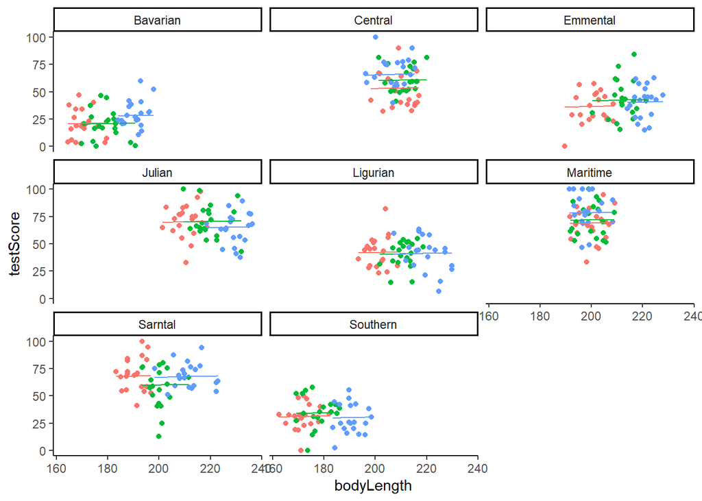

```r
(mm_plot <- ggplot(dragons, aes(x = bodyLength, y = testScore, colour = site)) +
  facet_wrap(~mountainRange, nrow=3) +
  geom_point() +
  theme_classic() +
  geom_line(data = cbind(dragons, pred = predict(mixed.lmer2)), aes(y = pred)) +
  theme(legend.position = "none"))
```

```r
library(stargazer)
stargazer(mixed.lmer2, type = "text",
          digits = 3,
          star.cutoffs = c(0.05, 0.01, 0.001),
          digit.separator = "")
```

```
##
## =================================================
##                          Dependent variable:
##                     -----------------------------
##                               testScore
## -------------------------------------------------
## bodyLength2                     0.831
##                                (1.681)
##
## Constant                      50.386***
##                                (6.507)
##
## -------------------------------------------------
## Observations                     480
## Log Likelihood                -1985.195
## Akaike Inf. Crit.             3980.389
## Bayesian Inf. Crit.           4001.258
## =================================================
## Note:               *p<0.05; **p<0.01; ***p<0.001
```

Reference: https://ourcodingclub.github.io/2017/03/15/mixed-models.html#nested

## Extended mixed models

Dealing with heteroscidacity within group

```r
library(nlme)
```

Vonesh and Carter (1992) describe and analyze data measured on highﬂux hemodialyzers to assess their in vivo ultraﬁltration characteristics. The ultraﬁltration rates (in ml/hr) of 20 high-ﬂux dialyzers were measured at 7 ascending transmembrane pressures (in dmHg). The in vitro evaluation of the dialyzers used bovine blood at ﬂow rates of either 200 dl/min or 300dl/min.

```r
head(Dialyzer)
```

```
## Grouped Data: rate ~ pressure | Subject
##   Subject  QB pressure   rate index
## 1       1 200    0.240  0.645     1
## 2       1 200    0.505 20.115     2
## 3       1 200    0.995 38.460     3
## 4       1 200    1.485 44.985     4
## 5       1 200    2.020 51.765     5
## 6       1 200    2.495 46.575     6
```

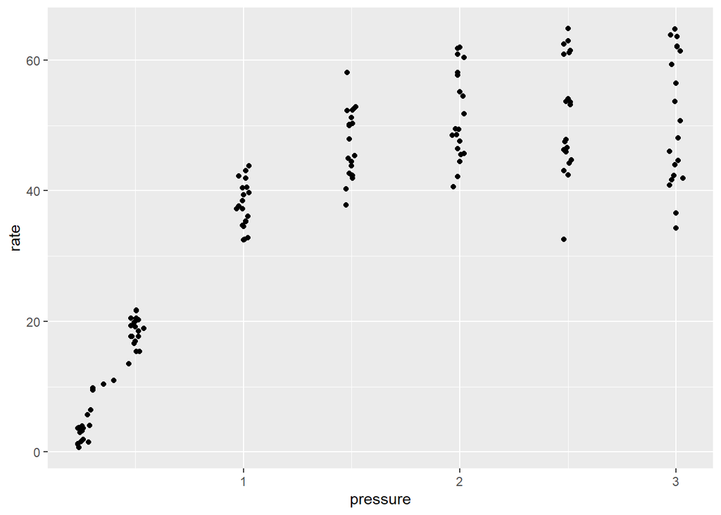

```r
qplot(data = Dialyzer, x = pressure, y = rate)
```

Итак, мы знаем, что у нас есть гетероскедастичность в данных, но давайте попробуем всё равно зафитить модель с допущением о гомоскедастичности

```r
fm1Dial.lme <- lme(rate ~(pressure + pressure^2 + pressure^3 + pressure^4)*QB, Dialyzer, ~ pressure + pressure^2)
fm1Dial.lme
```

```
## Linear mixed-effects model fit by REML
##   Data: Dialyzer
##   Log-restricted-likelihood: -505.2249
##   Fixed: rate ~ (pressure + pressure^2 + pressure^3 + pressure^4) * QB
##    (Intercept)       pressure          QB300 pressure:QB300
##      14.116623      12.733753      -3.155445       6.854329
##
## Random effects:
##  Formula: ~pressure + pressure^2 | Subject
##  Structure: General positive-definite, Log-Cholesky parametrization
##             StdDev       Corr
## (Intercept) 4.203782e-04 (Intr)
## pressure    3.892007e-05 0
## Residual    9.340306e+00
##
## Number of Observations: 140
## Number of Groups: 20
```

Это было нужно, чтобы посмотреть на residuals

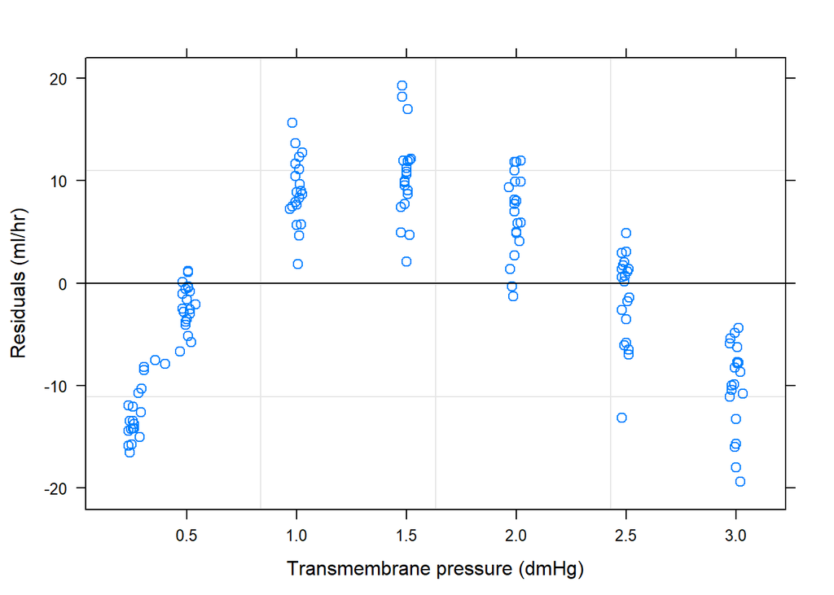

```r
plot(fm1Dial.lme, resid(.) ~ pressure, abline = 0)
```

Зафитим модель с varPower, который разрешает гетероскедастичность

```r
fm2Dial.lme <- update(fm1Dial.lme, weights = varPower(form = ~ pressure))
fm2Dial.lme
```

```
## Linear mixed-effects model fit by REML
##   Data: Dialyzer
##   Log-restricted-likelihood: -488.4504
##   Fixed: rate ~ (pressure + pressure^2 + pressure^3 + pressure^4) * QB
##    (Intercept)       pressure          QB300 pressure:QB300
##      39.371564       1.476843      -4.547118       7.515562
##
## Random effects:
##  Formula: ~pressure + pressure^2 | Subject
##  Structure: General positive-definite, Log-Cholesky parametrization
##             StdDev       Corr
## (Intercept) 2.258413e-07 (Intr)
## pressure    1.266952e+00 -0.805
## Residual    8.789985e+00
##
## Variance function:
##  Structure: Power of variance covariate
##  Formula: ~pressure
##  Parameter estimates:
##    power
## -1.02574
## Number of Observations: 140
## Number of Groups: 20
```

```r
anova(fm1Dial.lme, fm2Dial.lme)
```

```
##             Model df       AIC      BIC    logLik   Test  L.Ratio p-value
## fm1Dial.lme     1  8 1026.4497 1049.751 -505.2249
## fm2Dial.lme     2  9  994.9008 1021.115 -488.4504 1 vs 2 33.54891  <.0001
```

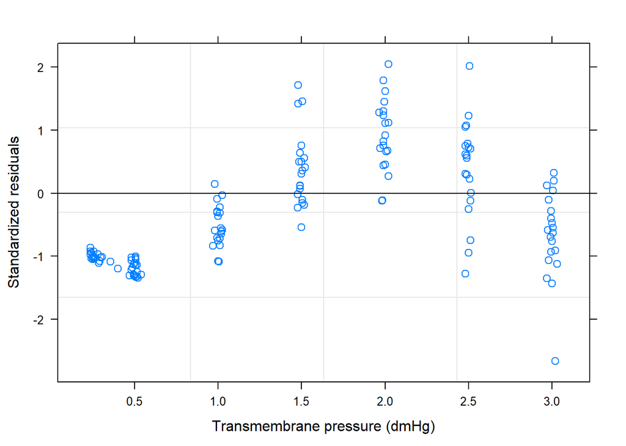

```r
plot(fm2Dial.lme, resid(., type = "p") ~ pressure, abline = 0)
```

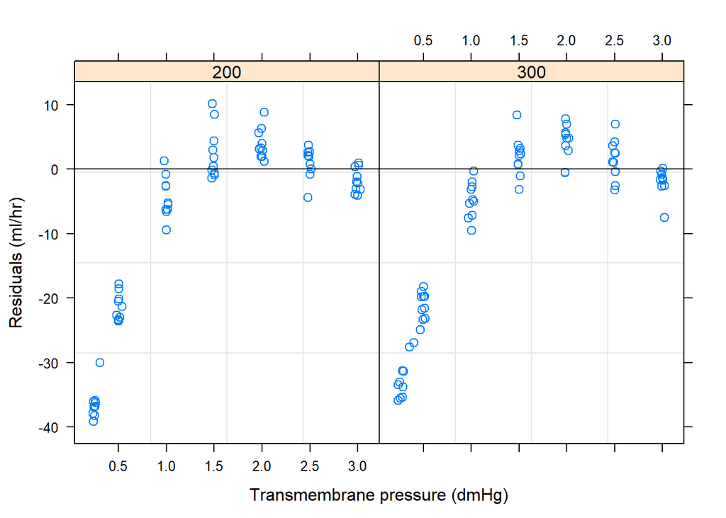

```r
plot(fm2Dial.lme, resid(.) ~ pressure|QB, abline = 0)
```

```r
fm3Dial.lme <- update(fm2Dial.lme, weights=varPower(form = ~ pressure | QB))
fm3Dial.lme
```

```
## Linear mixed-effects model fit by REML
##   Data: Dialyzer
##   Log-restricted-likelihood: -488.0796
##   Fixed: rate ~ (pressure + pressure^2 + pressure^3 + pressure^4) * QB
##    (Intercept)       pressure          QB300 pressure:QB300
##     40.9613178      0.8499736     -7.9973856      8.8838475
##
## Random effects:
##  Formula: ~pressure + pressure^2 | Subject
##  Structure: General positive-definite, Log-Cholesky parametrization
##             StdDev       Corr
## (Intercept) 3.257766e-07 (Intr)
## pressure    1.263200e+00 -0.794
## Residual    8.755977e+00
##
## Variance function:
##  Structure: Power of variance covariate, different strata
##  Formula: ~pressure | QB
##  Parameter estimates:
##        200        300
## -1.1264263 -0.9241348
## Number of Observations: 140
## Number of Groups: 20
```

```r
anova(fm2Dial.lme, fm3Dial.lme)
```

```
##             Model df      AIC      BIC    logLik   Test   L.Ratio p-value
## fm2Dial.lme     1  9 994.9008 1021.115 -488.4504
## fm3Dial.lme     2 10 996.1592 1025.286 -488.0796 1 vs 2 0.7416725  0.3891
```

```r
fm4Dial.lme <- update(fm2Dial.lme, weights = varConstPower(form = ~ pressure))
fm4Dial.lme
```

```
## Linear mixed-effects model fit by REML
##   Data: Dialyzer
##   Log-restricted-likelihood: -485.6814
##   Fixed: rate ~ (pressure + pressure^2 + pressure^3 + pressure^4) * QB
##    (Intercept)       pressure          QB300 pressure:QB300
##      37.062895       2.589455      -4.903072       7.665911
##
## Random effects:
##  Formula: ~pressure + pressure^2 | Subject
##  Structure: General positive-definite, Log-Cholesky parametrization
##             StdDev       Corr
## (Intercept) 1.193919e-07 (Intr)
## pressure    1.232419e+00 -0.944
## Residual    3.595052e+00
##
## Variance function:
##  Structure: Constant plus power of variance covariate
##  Formula: ~pressure
##  Parameter estimates:
##      const      power
##  0.9080991 -1.7268258
## Number of Observations: 140
## Number of Groups: 20
```

```r
anova(fm2Dial.lme, fm4Dial.lme)
```

```
##             Model df      AIC      BIC    logLik   Test  L.Ratio p-value
## fm2Dial.lme     1  9 994.9008 1021.115 -488.4504
## fm4Dial.lme     2 10 991.3629 1020.489 -485.6814 1 vs 2 5.537935  0.0186
```

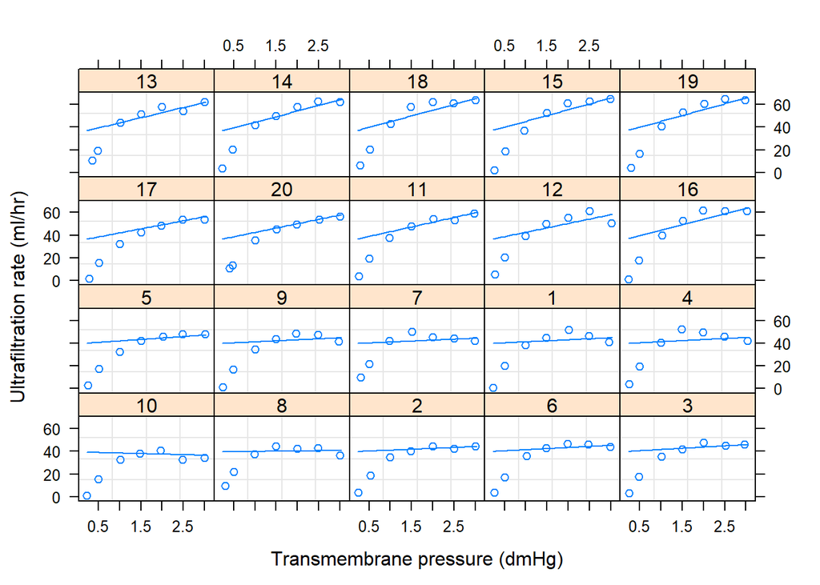

```r
plot(augPred(fm2Dial.lme), grid = T)
```

```r
anova(fm2Dial.lme)
```

```
##             numDF denDF  F-value p-value
## (Intercept)     1   118 4082.953  <.0001
## pressure        1   118   54.812  <.0001
## QB              1    18   51.798  <.0001
## pressure:QB     1   118   28.088  <.0001
```

**Что тут происходит?**

## Датасеты для отчаянных

Бооольше датасетоооов аааа

Crossed effects

```r
data(abrasion, package="faraway")
head(abrasion)
```

```
##   run position material wear
## 1   1        1        C  235
## 2   1        2        D  236
## 3   1        3        B  218
## 4   1        4        A  268
## 5   2        1        A  251
## 6   2        2        B  241
```

Nested effects

```r
data(eggs, package="faraway")
summary(eggs)
```

```
##       Fat          Lab    Technician Sample
##  Min.   :0.0600   I  :8   one:24     G:24
##  1st Qu.:0.3075   II :8   two:24     H:24
##  Median :0.3700   III:8
##  Mean   :0.3875   IV :8
##  3rd Qu.:0.4300   V  :8
##  Max.   :0.8000   VI :8
```

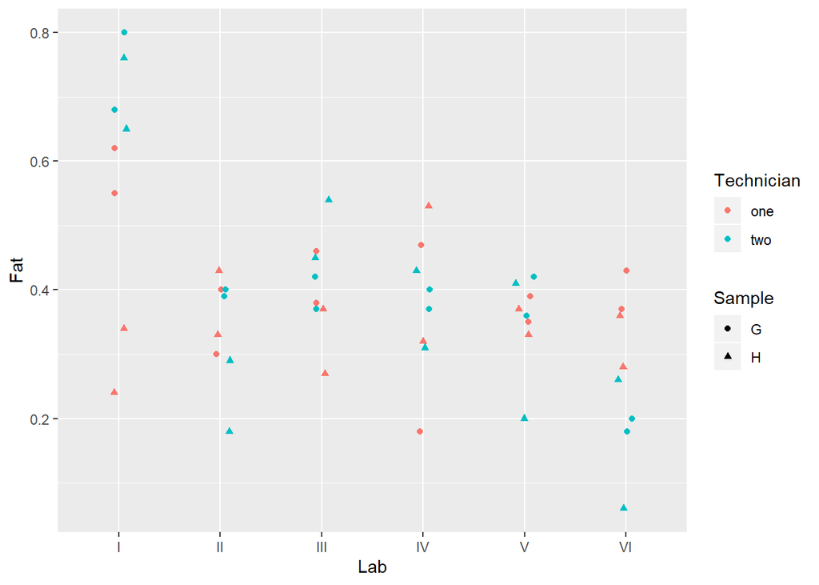

```r
ggplot(eggs, aes(y=Fat, x=Lab, color=Technician, shape=Sample)) + geom_point(position = position_jitter(width=0.1, height=0.0))
```

```r
cmod <- lmer(Fat ~ 1 + (1|Lab) + (1|Lab:Technician) + (1|Lab:Technician:Sample), data=eggs)
summary(cmod)
```

```
## Linear mixed model fit by REML ['lmerMod']
## Formula:
## Fat ~ 1 + (1 | Lab) + (1 | Lab:Technician) + (1 | Lab:Technician:Sample)
##    Data: eggs
##
## REML criterion at convergence: -64.2
##
## Scaled residuals:
##      Min       1Q   Median       3Q      Max
## -2.04098 -0.46571  0.00925  0.59713  1.54276
##
## Random effects:
##  Groups                Name        Variance Std.Dev.
##  Lab:Technician:Sample (Intercept) 0.003065 0.05536
##  Lab:Technician        (Intercept) 0.006981 0.08355
##  Lab                   (Intercept) 0.005918 0.07693
##  Residual                          0.007196 0.08483
## Number of obs: 48, groups:
## Lab:Technician:Sample, 24; Lab:Technician, 12; Lab, 6
##
## Fixed effects:
##             Estimate Std. Error t value
## (Intercept)  0.38750    0.04296    9.02
```